# Run Modular Discretization LITTLE MILLSEAT

### Step 4.4: Calculate the lumped weighting matrix which shows the number of cells from one HRU to contribute to downstream HRUs.

Note: I have rewritten the code here. The previous run time for this chunk was 10 minutes. Now it is about 10 seconds.

```r
print('Running weighting matrix...')
```

```
[1] "Running weighting matrix..."
```

```r
no.HRU.lump <- length(unique(HRU.lump))
list.HRU.lump <- unique(HRU.lump)

downstream.weighting.matrix.lump <- matrix(nrow=length(unique(HRU.lump)),ncol=length(unique(HRU.lump)))
start.time <- Sys.time()
for (i in 1:no.HRU.lump) {
  print(list.HRU.lump[i])
  for (j in 1:no.HRU.lump) {
    downstream.weighting.matrix.lump[i,j] <- sum((HRU.lump.matrix==list.HRU.lump[i])&(fdr.downstream.lump.matrix==list.HRU.lump[j]),
                                                 na.rm=T)
  }
}
```

```
[1] 1
[1] 110
[1] 120
[1] 130
[1] 140
[1] 150
[1] 160
[1] 170
[1] 180
[1] 190
[1] 200
[1] 210
[1] 220
[1] 230
[1] 240
[1] 250
[1] 260
[1] 270
[1] 280
[1] 290
[1] 300
```

```r
end.time <- Sys.time()
end.time-start.time
```

```
Time difference of 6.4091 secs
```

```r
options("scipen"=100, "digits"=5)

rownames(downstream.weighting.matrix.lump) <- unique(HRU.lump)
colnames(downstream.weighting.matrix.lump) <- unique(HRU.lump)

weighting.matrix.lump <- downstream.weighting.matrix.lump/rowSums(downstream.weighting.matrix.lump)

rownames(weighting.matrix.lump) <- unique(HRU.lump)
colnames(weighting.matrix.lump) <- unique(HRU.lump)

rowSums(weighting.matrix.lump)
```

```
  1 110 120 130 140 150 160 170 180 190 200 210 220 230 240 250 260 270 280 290 300
  1   1   1   1   1   1   1   1   1   1   1   1   1   1   1   1   1   1   1   1   1
```

## Step 5: Create the Groups Matrix

Next, we will create a “Groups” matrix which will specify the initial parameters for dynamic TOPMODEL.

Note - I did notice some differences between atb.bar from the 20 HRUs discretized here and the 2- HRUs discretized with dynatopmodel. It is related to how the HRUs are discretized. There is more variability with the dynatopmodel approach.

Items we will need to include in the table:

- id - the ID of the channel, typically channels are ranked 0-100 and HRUs are ranked based on TWI with ID > 100
- tag - same as id
- chan.no - the channel number (note - only for IDs classified as channels)
- area_pc - the percent area that the HRU takes up
- area - the area m^2 that the HRU takes up
- sbar - the average slope of the HRU (m/m)
- atb.bar - the average TWI for the HRU
- gauge.id - the rain gauge contributing to the HRU
- catch.id - the catchment in which the HRU is situated
- srz_max - maximum depth of root zone parameter value initialized as 0.1
- ln_t0 - ln t0 parameter value initialized as 7
- m - exponential decline of transmissivity parameter initialized as 0.01
- srz0 - initial root zone storage parameter initialized as 0
- td - td parameter initialized as 1
- vchan - v chan parameter (for channels only) parameterized as 1000
- vof - overland v parameter (for HRUs only) parameterized as 100
- k0 - k0 parameter initialized as 1e+8
- CD - CD parameter (unused) initialized as 0.1
- sd_max - sd_max parameter initialized as 0.5
- pe_fact - potential evapotranspiration factor used to scale PET, initialized as 1
- vof_fact - vof factor initialized as 1
- rain_fact - rain factor used to scale precip amount, initialized as 1
- mann.n - mannings n initialized as 0.01
- S0 - initial slope, parameterized as 0.1
- ex_max - ex max parameterized as 1

### Step 5.1 Create the groups matrix for the explicit reaches

```r
# Enter the cell size
cell.size <- as.numeric(readline('Enter the resolution of the raster in m (for 10-m raster enter 10): '))
1.524

# Create functions to determine the area of the raster
area_cell <- function(raster.matrix,raster_ID) {
  area_c <- sum(raster.matrix==raster_ID, na.rm=T)
  return(area_c)
}

# Create function to determine the zonal mean (unused)
mean_raster <- function(raster.matrix, HRU.matrix, raster_ID) {
  mean_rast <- mean(raster.matrix[HRU.matrix==raster_ID],na.rm=T)
  return(mean_rast)
}

# Calculate the slope
slope <- terrain(dem,opt='slope',units='tangent')

# Initial ize the groups
groups.explicit <- data.frame(matrix(nrow=length(unique(HRU)),ncol=26))
names(groups.explicit) <- c('id','tag','chan.no','order','area_pc','area','sbar','atb.bar','gauge.id','catch.id','srz_max','ln_t0','m','srz0','td','vchan','vof','k0','CD','sd_max','pe_fact','vof_fact','rain_fact','mann.n','S0','ex_max')

# Assign the groups
groups.explicit$id <- unique(HRU)
groups.explicit$tag <- unique(HRU)
groups.explicit$chan.no[1:length(unique(stream))] <- unique(stream)
groups.explicit$order <- 1:length(unique(HRU))
groups.explicit$area_pc <- sapply(X=groups.explicit$id,FUN=area_cell,raster.matrix=HRU.matrix)/sum(!is.na(HRU.matrix))*100
groups.explicit$area <- groups.explicit$area_pc*sum(!is.na(HRU.matrix))*cell.size^2/100
groups.explicit$sbar <- zonal(x=slope,z=HRU,fun='mean')[,2]
groups.explicit$atb.bar[(1+length(unique(stream))):length(unique(HRU))] <- zonal(x=TWI.dinf,z=HRU,fun='mean')[(1+length(unique(stream))):length(unique(HRU)),2]
groups.explicit$gauge.id <- 1
groups.explicit$catch.id <- 1
groups.explicit$srz_max <- 0.1
groups.explicit$ln_t0 <- 7
groups.explicit$m <- 0.01
groups.explicit$srz0 <- 0
groups.explicit$td <- 1
groups.explicit$vchan[1:length(unique(stream))] <- 1000
groups.explicit$vof[(1+length(unique(stream))):length(unique(HRU))] <- 100
groups.explicit$k0 <- 1e+8
groups.explicit$CD <- 0.1
groups.explicit$sd_max <- 0.5
groups.explicit$pe_fact <- 1
groups.explicit$vof_fact <- 1
groups.explicit$rain_fact <- 1
groups.explicit$mann.n <- 0.01
groups.explicit$S0 <- 0.1
groups.explicit$ex_max <- 1


# Read the HRUs and assign unique soil groups

no.hru <- as.numeric(length(unique(HRU)))               # Calculate the number of unique HRUs from the spatial function

soils.param.explicit <- matrix(nrow=no.hru,ncol=1)                        # Initialize the soils vector

# Create a function to determine the mode - we will assign the soil type to the HRU based on which soil type appears most frequently for the HRU.

Mode <- function(x) {
  ux <- unique(x)
  ux[which.max(tabulate(match(x, ux)))]
}

hru.explicit.names <- unique(HRU)
for (i in 1:length(hru.explicit.names)) {                                # The loop will output the soil type for each HRU
  soil.type <- soils[HRU==hru.explicit.names[i]]     # Identifies the soil type for a corresponding HRU
  soils.param.explicit[i] <- Mode(soil.type)                                      # Since there are multiple HRU units, the first soil type belonging to the HRU will be read
 print(paste('Analyzing HRU',hru.explicit.names[i]))
}                                                               # End the loop
```

```
[1] "Analyzing HRU 1"
[1] "Analyzing HRU 2"
[1] "Analyzing HRU 3"
[1] "Analyzing HRU 4"
[1] "Analyzing HRU 5"
[1] "Analyzing HRU 6"
[1] "Analyzing HRU 7"
[1] "Analyzing HRU 8"
[1] "Analyzing HRU 9"
[1] "Analyzing HRU 10"
[1] "Analyzing HRU 11"
[1] "Analyzing HRU 12"
[1] "Analyzing HRU 13"
[1] "Analyzing HRU 14"
[1] "Analyzing HRU 15"
```

[output cut: 37 more lines]

```r
groups.explicit$soils.param <-    NA
groups.explicit$soils.param <- soils.param.explicit[,1]

# The soil type is bound to the groups layer
```

### Step 5.2: Create the groups matrix for the lumped reaches

```r
# Calculate the slope
slope <- terrain(dem,opt='slope',units='tangent')

# Initialize the groups
groups.lump <- data.frame(matrix(nrow=no.HRU.lump,ncol=26))
names(groups.lump) <- c('id','tag','chan.no','order','area_pc','area','sbar','atb.bar','gauge.id','catch.id','srz_max','ln_t0','m','srz0','td','vchan','vof','k0','CD','sd_max','pe_fact','vof_fact','rain_fact','mann.n','S0','ex_max')

# Assign the groups
groups.lump$id <- list.HRU.lump
groups.lump$tag <- list.HRU.lump
groups.lump$chan.no[1:length(unique(stream.lump))] <- unique(stream.lump)
groups.lump$order <- 1:no.HRU.lump
groups.lump$area_pc <- sapply(X=groups.lump$id,
                         FUN=area_cell,raster.matrix=HRU.lump.matrix)/sum(!is.na(HRU.lump.matrix))*100
groups.lump$area <- groups.lump$area_pc*sum(!is.na(HRU.lump.matrix))*cell.size^2/100
groups.lump$sbar <- zonal(x=slope,z=HRU.lump,fun='mean')[,2]
groups.lump$atb.bar[(1+length(unique(stream.lump))):length(unique(HRU.lump))] <- zonal(x=TWI.dinf,z=HRU.lump,fun='mean')[(1+length(unique(stream.lump))):length(unique(HRU.lump)),2]
groups.lump$gauge.id <- 1
groups.lump$catch.id <- 1
groups.lump$srz_max <- 0.1
groups.lump$ln_t0 <- 7
groups.lump$m <- 0.01
groups.lump$srz0 <- 0
groups.lump$td <- 1
groups.lump$vchan[1:length(unique(stream.lump))] <- 1000
groups.lump$vof[(1+length(unique(stream.lump))):length(unique(HRU.lump))] <- 100
groups.lump$k0 <- 1e+8
groups.lump$CD <- 0.1
groups.lump$sd_max <- 0.5
groups.lump$pe_fact <- 1
groups.lump$vof_fact <- 1
groups.lump$rain_fact <- 1
groups.lump$mann.n <- 0.01
groups.lump$S0 <- 0.1
groups.lump$ex_max <- 1



# Read the HRUs and assign unique soil groups

no.hru <- as.numeric(length(unique(HRU.lump)))               # Calculate the number of unique HRUs from the spatial function

soils.param.lump <- matrix(nrow=no.hru,ncol=1)                                        # Initialize the soils vector

# Create a function to determine the mode - we will assign the soil type to the HRU based on which soil type appears most frequently for the HRU.

Mode <- function(x) {
  ux <- unique(x)
  ux[which.max(tabulate(match(x, ux)))]
}

hru.lump.names <- unique(HRU.lump)
for (i in 1:length(hru.lump.names)) {                                # The loop will output the soil type for each HRU
  soil.type <- soils[HRU.lump==hru.lump.names[i]]      # Identifies the soil type for a corresponding HRU
  soils.param.lump[i] <- Mode(soil.type)                                      # Since there are multiple HRU units, the first soil type belonging to the HRU will be read
 print(paste('Analyzing HRU',hru.lump.names[i]))
}                                                               # End the loop
```

```
[1] "Analyzing HRU 1"
[1] "Analyzing HRU 110"
[1] "Analyzing HRU 120"
[1] "Analyzing HRU 130"
[1] "Analyzing HRU 140"
[1] "Analyzing HRU 150"
[1] "Analyzing HRU 160"
[1] "Analyzing HRU 170"
[1] "Analyzing HRU 180"
[1] "Analyzing HRU 190"
[1] "Analyzing HRU 200"
[1] "Analyzing HRU 210"
[1] "Analyzing HRU 220"
[1] "Analyzing HRU 230"
[1] "Analyzing HRU 240"
[1] "Analyzing HRU 250"
[1] "Analyzing HRU 260"
[1] "Analyzing HRU 270"
[1] "Analyzing HRU 280"
[1] "Analyzing HRU 290"
[1] "Analyzing HRU 300"
```

```r
groups.lump$soils.param <-    soils.param.lump[,1]                 # The soil type is bound to the groups layer
```

## Step 6: Routing Matrix

In this step, we will create routing matrix that bins lists the length of each cell to the outlet and the frequency.

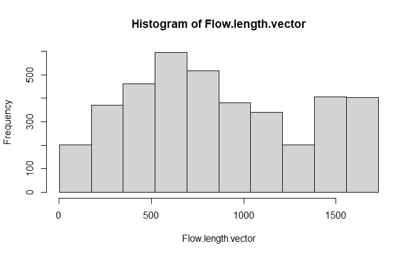

```r
# Determine the flow length from each cell in the stream to the catchment outlet
outFlowLength <- arcpy$sa$FlowLength('SpatialInputData/lm_fdr',"DOWNSTREAM")
# Note - the next line only needs to be saved once.
arcpy$env$overwriteOutput <- T
outFlowLength$save(paste0(getwd(),'/SpatialInputData/Flow_length.tif'))

Flow.length <- raster('SpatialInputData/Flow_length.tif')
Flow.length.stream <- stream.lump
Flow.length.stream[!is.na(stream.lump)] <- Flow.length[stream.lump==1]
writeRaster(Flow.length.stream,'SpatialInputData/Flow_length_stream.tif', overwrite =T)

input.units <- readline('Was the original DEM in units of ft or m (enter ft or m): ')
ft

breaks.hist <- 10      # User defined number of breaks

RoutingTable <- data.frame(matrix(nrow=breaks.hist,ncol=2))
names(RoutingTable) <- c('flow.len', 'prop')

if(input.units == 'ft') {
  Flow.length.stream.fix <- Flow.length.stream * 0.3048
  Flow.length.vector <- na.omit(as.numeric(as.vector(Flow.length.stream.fix)))

  RoutingHist <- hist(Flow.length.vector,breaks=seq(min(Flow.length.vector),max(Flow.length.vector),length.out=breaks.hist+1))
  RoutingTable$flow.len <- RoutingHist$breaks[-1]
  RoutingTable$prop <- RoutingHist$counts/sum(RoutingHist$counts)

} else if (input.units == 'm') {
  Flow.length.vector <- na.omit(as.numeric(as.vector(Flow.length.stream)))
  RoutingHist <- hist(Flow.length.vector,breaks=seq(min(Flow.length.vector),max(Flow.length.vector),length.out=breaks.hist+1))
  RoutingTable$flow.len <- RoutingHist$breaks[-1]
  RoutingTable$prop <- RoutingHist$counts/sum(RoutingHist$counts)
} else {
  'invalid response, RoutingTable not calculated.'
}
```